# Coursera - Practical Machine Learning - Course Project

Komal Kukreja

Sunday, October 25, 2015

#### Overview

Using devices such as Jawbone Up, Nike FuelBand, and Fitbit it is now possible to collect a large amount of data about personal activity relatively inexpensively. These type of devices are part of the quantified self movement – a group of enthusiasts who take measurements about themselves regularly to improve their health, to find patterns in their behavior, or because they are tech geeks. One thing that people regularly do is quantify how much of a particular activity they do, but they rarely quantify how well they do it. In this project, our goal will is to use data from accelerometers on the belt, forearm, arm, and dumbell of 6 participants.

#### Data Source

The training data for this project are available here: https://d396qusza40orc.cloudfront.net/predmachlearn/pml-training.csv

The test data are available here: https://d396qusza40orc.cloudfront.net/predmachlearn/pml-testing.csv

The data for this project come from this source: http://groupware.les.inf.puc-rio.br/har.

#### Loading dependencies

```r
library(caret)
library(randomForest)
library(rpart)
library(rpart.plot)
```

#### Getting Data

```r
setwd("H:/Komal/Data Science Specialization/Module 8_Practical Machine Learning/Course Project")

train_file <- "pml-training.csv"
test_file <- "pml-testing.csv"

#download.file("https://d396qusza40orc.cloudfront.net/predmachlearn/pml-training.csv",
#              destfile = train_file)
#download.file("https://d396qusza40orc.cloudfront.net/predmachlearn/pml-testing.csv",
#              destfile = test_file)
```

#### Reading Data

```r
read_train <- read.csv(train_file, header=TRUE)
read_test <- read.csv(test_file, header=TRUE)
```

#### Basic Exploratory Data Analyses

```r
str(read_train)
```

```
## 'data.frame':    19622 obs. of  160 variables:
##  $ X                       : int  1 2 3 4 5 6 7 8 9 10 ...
##  $ user_name               : Factor w/ 6 levels "adelmo","carlitos",..: 2 2 2 2 2 2 2 2 2 2 ...
##  $ raw_timestamp_part_1    : int  1323084231 1323084231 1323084231 1323084232 1323084232 1323084232 1323084232 1323084232 1323084232 1323084232 ...
##  $ raw_timestamp_part_2    : int  788290 808298 820366 120339 196328 304277 368296 440390 484323 484434 ...
##  $ cvtd_timestamp          : Factor w/ 20 levels "02/12/2011 13:32",..: 9 9 9 9 9 9 9 9 9 9 ...
##  $ new_window              : Factor w/ 2 levels "no","yes": 1 1 1 1 1 1 1 1 1 1 ...
##  $ num_window              : int  11 11 11 12 12 12 12 12 12 12 ...
##  $ roll_belt               : num  1.41 1.41 1.42 1.48 1.48 1.45 1.42 1.42 1.43 1.45 ...
##  $ pitch_belt              : num  8.07 8.07 8.07 8.05 8.07 8.06 8.09 8.13 8.16 8.17 ...
##  $ yaw_belt                : num  -94.4 -94.4 -94.4 -94.4 -94.4 -94.4 -94.4 -94.4 -94.4 -94.4 ...
##  $ total_accel_belt        : int  3 3 3 3 3 3 3 3 3 3 ...
##  $ kurtosis_roll_belt      : Factor w/ 397 levels "","-0.016850",..: 1 1 1 1 1 1 1 1 1 1 ...
##  $ kurtosis_picth_belt     : Factor w/ 317 levels "","-0.021887",..: 1 1 1 1 1 1 1 1 1 1 ...
##  $ kurtosis_yaw_belt       : Factor w/ 2 levels "","#DIV/0!": 1 1 1 1 1 1 1 1 1 1 ...
```

[output cut: 86 more lines]

#### Cleaning Data

I prepared a model containing variables having ‘accel’ in their name to predict variable classe. This gave accuracy of 95%. I modified the model by adding variables to it that had ‘gyros’ in their name. This gave an accuracy of 97%. I again modified it by adding variables having ‘magnet’ in their name. This gave an accuracy of 98%. I have finalised this model for prediction. Also, as the accuracy went on increasing, the out of sample error went on decreasing.

```r
# filtering variables
all_variables_train <- colnames(read_train)
filter_variables_train <- colnames(read_train)[grep("accel|gyros|magnet|classe",all_variables_train)]
filter_train_frame <- read_train[, filter_variables_train]
# removing columns contaning NA values from training data
filter_train_frame <- filter_train_frame[, colSums(is.na(filter_train_frame)) == 0]
read_test <- read_test[, colSums(is.na(read_test)) == 0]
```

#### Model Fitting

```r
# Partitioning the above training dataset/frame into training and testing sets
inTrain = createDataPartition(filter_train_frame$classe, p = 0.7, list=FALSE)
training = filter_train_frame[ inTrain,]
testing = filter_train_frame[-inTrain,]
set.seed(1)
fit <- randomForest(classe ~ ., data=training)
```

#### Prediction

```r
prediction <- predict(fit, testing, type="class")
```

#### Cross validation and out of sample error (OOB)

```r
print(fit)
```

```
##
## Call:
##  randomForest(formula = classe ~ ., data = training)
##                Type of random forest: classification
##                      Number of trees: 500
## No. of variables tried at each split: 6
##
##         OOB estimate of  error rate: 1.33%
## Confusion matrix:
##      A    B    C    D    E class.error
## A 3891    5    1    8    1 0.003840246
## B   24 2608   24    1    1 0.018811136
## C    3   28 2363    2    0 0.013772955
## D    3    0   60 2181    8 0.031527531
## E    1    3    2    8 2511 0.005544554
```

```r
confusionMatrix(prediction, testing$classe)
```

```
## Confusion Matrix and Statistics
##
##           Reference
## Prediction    A    B    C    D    E
##          A 1667   22    1    4    0
##          B    3 1102   15    0    0
##          C    1   15 1009   24    3
##          D    3    0    1  936    4
##          E    0    0    0    0 1075
##
## Overall Statistics
##
##                Accuracy : 0.9837
##                  95% CI : (0.9801, 0.9868)
##     No Information Rate : 0.2845
##     P-Value [Acc > NIR] : < 2.2e-16
##
##                   Kappa : 0.9794
##  Mcnemar's Test P-Value : NA
##
## Statistics by Class:
##
##                      Class: A Class: B Class: C Class: D Class: E
## Sensitivity            0.9958   0.9675   0.9834   0.9710   0.9935
## Specificity            0.9936   0.9962   0.9912   0.9984   1.0000
## Pos Pred Value         0.9841   0.9839   0.9591   0.9915   1.0000
## Neg Pred Value         0.9983   0.9922   0.9965   0.9943   0.9985
## Prevalence             0.2845   0.1935   0.1743   0.1638   0.1839
## Detection Rate         0.2833   0.1873   0.1715   0.1590   0.1827
## Detection Prevalence   0.2879   0.1903   0.1788   0.1604   0.1827
## Balanced Accuracy      0.9947   0.9819   0.9873   0.9847   0.9968
```

#### Plots

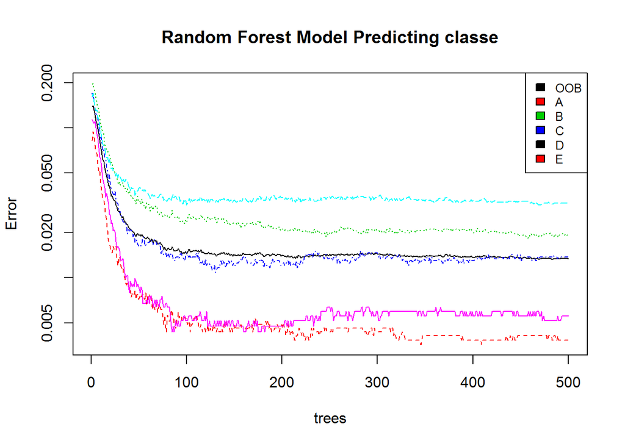

```r
plot(fit, type='l', log='y',main='Random Forest Model Predicting classe')
legend("topright", colnames(fit$err.rate),col=1:4,cex=0.8,fill=1:4)
```

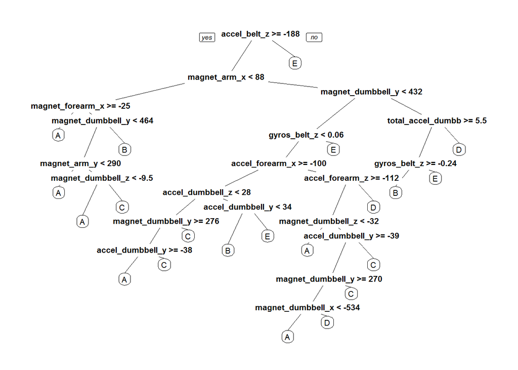

```r
treePlot <- rpart(classe ~ ., data=training, method="class")
prp(treePlot)
```

#### Predicting for 20 problems for submission part:

```r
# removing columns contaning NA values from testing data
read_test <- read_test[, colSums(is.na(read_test)) == 0]
problem_result <- predict(fit, read_test, type="class")
print(problem_result)
```

```
##  1  2  3  4  5  6  7  8  9 10 11 12 13 14 15 16 17 18 19 20
##  B  A  B  A  A  E  D  B  A  A  B  C  B  A  E  E  A  B  B  B
## Levels: A B C D E
```

```r
# writing output files
pml_write_files = function(x){
  n = length(x)
  for(i in 1:n){
    filename = paste0("problem_id_",i,".txt")
    write.table(x[i],file=filename,quote=FALSE,row.names=FALSE,col.names=FALSE)
  }
}
# Executing above funciton
pml_write_files(problem_result)
```